# notebook

### Student Name: Sameer Anees Jaliawala

### Student ID: sj02732

### Student Email: sj02732@st.habib.edu.pk

## Case Study 1: Google Play Store apps and reviews

Mobile apps are everywhere. They are easy to create and can be lucrative. Because of these two factors, more and more apps are being developed. In this notebook, we will do a comprehensive analysis of the Android app market by comparing over ten thousand apps in Google Play across different categories. We'll look for insights in the data to devise strategies to drive growth and retention.

Let's take a look at the data, which consists of two files:

- `apps.csv`: contains all the details of the applications on Google Play. There are 13 features that describe a given app.
- `user_reviews.csv`: contains 100 reviews for each app, [most helpful first](https://www.androidpolice.com/2019/01/21/google-play-stores-redesigned-ratings-and-reviews-section-lets-you-easily-filter-by-star-rating/). The text in each review has been pre-processed and attributed with three new features: Sentiment (Positive, Negative or Neutral), Sentiment Polarity and Sentiment Subjectivity.

## 1. Import Data

```python
# Read in dataset
import pandas as pd

df = pd.read_csv("datasets/apps.csv")

# Drop duplicates
apps = df.drop_duplicates()

# Print the total number of apps
print('Total number of apps in the dataset = ', len(apps.index))

# Print random sample of 5 entries
print(apps.sample(n=5))
```

```
Total number of apps in the dataset =  9659
      Unnamed: 0                          App            Category  Rating  \
3330        4201              H letter images              SOCIAL     NaN
1901        2423                   ABG Master             MEDICAL     NaN
1050        1279  Abs Training-Burn belly fat  HEALTH_AND_FITNESS     4.7
9632       10814         FR: My Secret Pets!               FAMILY     4.0
4593        5564                AR Dragon Pet              FAMILY     NaN

      Reviews  Size  Installs  Type  Price Content Rating            Genres  \
3330       17  8.5M    1,000+  Free      0           Teen            Social
1901        2  1.8M       50+  Paid  $0.99       Everyone           Medical
1050     2071  6.9M  100,000+  Free      0       Everyone  Health & Fitness
9632      785   31M   50,000+  Free      0           Teen     Entertainment
4593        0   NaN   50,000+  Free      0       Everyone            Casual

          Last Updated         Current Ver         Android Ver
3330     June 28, 2018                16.7        4.0.3 and up
1901    August 4, 2018                 1.1          4.1 and up
1050     July 24, 2018              1.0.12          4.1 and up
9632      June 3, 2015               1.3.1          3.0 and up
4593  November 9, 2017  Varies with device  Varies with device
```

## 2. Data cleaning

The three features that we will be working with most frequently henceforth are `Installs`, `Size`, and `Price`. A careful glance of the dataset reveals that some of these columns mandate data cleaning in order to be consumed by code we'll write later. Specifically, the presence of special characters (`, $ +`) and letters (`M k`) in the `Installs`, `Size`, and `Price` columns. Also it make their conversion to a numerical data type difficult. Let's clean by removing these and converting each column to a numeric type.

```python
chars_to_remove = [',','+','k','M','$']
cols_to_clean = ['Installs','Size','Price']

# Loop for each column and characters
for j in cols_to_clean:
    for i in chars_to_remove:
        apps[j]= apps[j].str.replace(i,'')
# Convert cols to numeric
apps[cols_to_clean]= apps[cols_to_clean].apply(pd.to_numeric)
```

There is not much to analyze the data here then to say that we first replace fields that contain the characters in **chars_to_remove** from the **cols_to_clean** array using nested loops and *pd.str.replace* function, then we convert these columns to numeric using *apply* function, that is used in dataframes, and *pd.to_numeric.*

## 3. Exploring app categories

With more than 1 billion active users in 190 countries around the world, Google Play continues to be an important distribution platform to build a global audience. For businesses to get their apps in front of users, it's important to make them more quickly and easily discoverable on Google Play. To improve the overall search experience, Google has introduced the concept of grouping apps into categories.

This brings us to the following questions:

- Which category has the highest share of (active) apps in the market?
- Is any specific category dominating the market?
- Which categories have the fewest number of apps?

```
Number of categories =  33
```

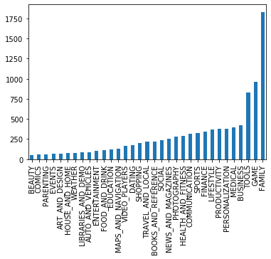

```python
#import your favourite library for visualization
import matplotlib.pyplot as plt
import seaborn as sns
# Print the total number of unique categories
num_categories = len(apps.Category.unique())
print('Number of categories = ', num_categories)

# Count the number of apps in each 'Category' and sort them for easier plotting
number=apps.Category.value_counts().sort_values()
# Plot any graph (bar,chart,line etc.) to show each category and its count for visualization
number.plot.bar()
plt.show()
```

We can first analyse that the number of unique categories are 33. From the graph we can notice that the **Family** Category has the most apps, whereas **Beauty** Category has the least apps in the app store. We have also imported both the seaborn and matplotlib.pyplot libraries because some of the functionalities are dependent on both later on.

## 4. Distribution of app ratings

After having witnessed the market share for each category of apps, let's see how all these apps perform on an average. App ratings (on a scale of 1 to 5) impact the discoverability, conversion of apps as well as the company's overall brand image. Ratings are a key performance indicator of an app.

Add Histogram plot to visualize the distribution of app ratings

```
Average app rating =  4.173243045387994
```

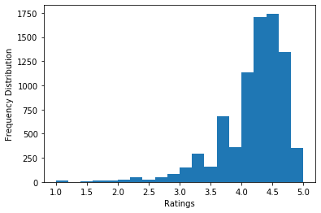

```python
# Overall Average rating of apps
avg_app_rating = apps.Rating.mean()
print('Average app rating = ', avg_app_rating)

# Distribution of apps according to their ratings using histogram. Write proper x axis and y axis labels.
apps.Rating.plot.hist(bins=20)
plt.xlabel("Ratings")
plt.ylabel("Frequency Distribution")
plt.show()
```

The Average app rating is **4.17** and from the graph we can notice that the highest rating is somwehere around **4.5**.

## 5. Size and price of an app

Let's now examine app size and app price. For size, if the mobile app is too large, it may be difficult and/or expensive for users to download. Lengthy download times could turn users off before they even experience your mobile app. Plus, each user's device has a finite amount of disk space. For price, some users expect their apps to be free or inexpensive. These problems compound if the developing world is part of your target market; especially due to internet speeds, earning power and exchange rates.

How can we effectively come up with strategies to size and price our app?

- Does the size of an app affect its rating?
- Do users really care about system-heavy apps or do they prefer light-weighted apps?
- Does the price of an app affect its rating?
- Do users always prefer free/cheaper apps over paid apps? What price range do majoriy of apps fall into?

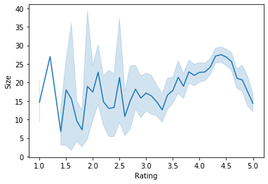

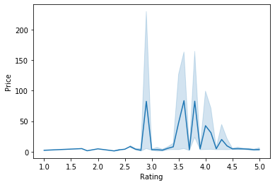

```python
# Get the subset for categories with at least 250 apps
subset=apps[apps.Category.isin(apps.Category.value_counts()[apps.Category.value_counts()>=250].index.values)]
# Plot size vs. rating
sns.lineplot(x='Rating',y='Size',data=subset)
plt.show()
# Subset for paid apps only
paid_apps = apps[apps.Type=="Paid"]
# Plot price vs. rating
sns.lineplot(x='Rating',y='Price',data=paid_apps)
plt.show()
```

We first get the subset where there are categories with atleat 250 apps using **value_counts**, that gives number of unique values for each *Category*, and **isin** functions. From the first graph, we can't really deduce the exact relationship between ratings and size. We then subset the data where there are only paid apps and then plot Price vs Rating, where again we can't deduce an exact relationship between Ratings and Price. Looks like size and price dont have a big influence on ratings, but it could have an influence on Installations

## 6. Relation between app category and app price

So now comes the hard part. How are companies and developers supposed to make ends meet? What monetization strategies can companies use to maximize profit? The costs of apps are largely based on features, complexity, and platform.

There are many factors to consider when selecting the right pricing strategy for your mobile app. It is important to consider the willingness of your customer to pay for your app. A wrong price could break the deal before the download even happens. Potential customers could be turned off by what they perceive to be a shocking cost, or they might delete an app they’ve downloaded after receiving too many ads or simply not getting their money's worth.

Different categories demand different price ranges. Some apps that are simple and used daily, like the calculator app, should probably be kept free. However, it would make sense to charge for a highly-specialized medical app that diagnoses diabetic patients.

- What is the maximum price for GAME category. What is the average price of paid GAME category?

```
maximum price for GAME category: 17.99
average price of paid GAME category: 3.46719512195122
```

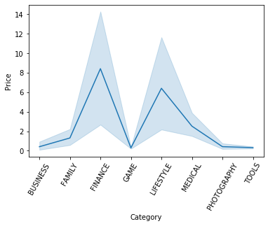

```python
# Select a few popular app categories
popular_app_cats = apps[apps.Category.isin(['GAME', 'FAMILY', 'PHOTOGRAPHY',
                                            'MEDICAL', 'TOOLS', 'FINANCE',
                                            'LIFESTYLE','BUSINESS'])]

# Examine and plot the price trend for the above categories
sns.lineplot(x="Category",y="Price",data=popular_app_cats)
plt.xticks(rotation=60)
# Examine GAME Category. What is the maximum price for GAME category. What is the average price of paid GAME category?
max_price=apps.Price[apps.Category=="GAME"].max()
paid_prices=apps.Price[apps.Type=="Paid"]
avg_price=paid_prices[apps.Category=="GAME"].mean()
print("maximum price for GAME category:",max_price)
print("average price of paid GAME category:",avg_price)
```

The maximum price for game category is 17.99 while the average price of paid game category is 3.47. From the graph we can see that the Finance and lifestyle apps have the most prices, while the business, game, tools and photography apps have the least prices

## 7. Filter out "junk" apps

It looks like a bunch of the really expensive apps are "junk" apps. That is, apps that don't really have a purpose. Some app developer may create an app called *I Am Rich Premium* or *most expensive app (H)* just for a joke or to test their app development skills. Some developers even do this with malicious intent and try to make money by hoping people accidentally click purchase on their app in the store.

Let's filter out these junk apps and re-do our visualization.

```
Junk Apps:
        Category                                App   Price
3327     FAMILY             most expensive app (H)  399.99
3465  LIFESTYLE                         💎 I'm rich  399.99
3469  LIFESTYLE           I'm Rich - Trump Edition  400.00
4396  LIFESTYLE                          I am rich  399.99
4398     FAMILY                     I am Rich Plus  399.99
4399  LIFESTYLE                      I am rich VIP  299.99
4400    FINANCE                  I Am Rich Premium  399.99
4401  LIFESTYLE                I am extremely Rich  379.99
4402    FINANCE                         I am Rich!  399.99
4403    FINANCE                 I am rich(premium)  399.99
4406     FAMILY                      I Am Rich Pro  399.99
4408    FINANCE     I am rich (Most expensive app)  399.99
4410     FAMILY                          I Am Rich  389.99
4413    FINANCE                          I am Rich  399.99
4417    FINANCE                 I AM RICH PRO PLUS  399.99
8577    MEDICAL                       EP Cook Book  200.00
8763    FINANCE                        Eu Sou Rico  394.99
8780  LIFESTYLE  I'm Rich/Eu sou Rico/أنا غني/我很有錢  399.99
```

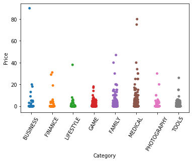

```python
# Select a few popular app categories
popular_app_cats = apps[apps.Category.isin(['GAME', 'FAMILY', 'PHOTOGRAPHY',
                                            'MEDICAL', 'TOOLS', 'FINANCE',
                                            'LIFESTYLE','BUSINESS'])]

# Category, Name and Price of apps priced above $100 which will be considered as Junk apps.
junk=popular_app_cats[popular_app_cats.Price>100]
junk1=junk[["Category","App","Price"]]
print("Junk Apps:\n",junk1)
# Select apps priced below $100 which will be considered as authentic apps.
auth_apps=popular_app_cats[~popular_app_cats.App.isin(junk1.App)]
auth_apps1=auth_apps[["Category","App","Price"]]
# Examine and visualize price vs category with the authentic apps. You can use strip  plot or box plot
plt.xticks(rotation=60)
sns.stripplot(y="Price",x="Category",data=auth_apps1)
```

Number of Junk apps from the popular categories subset are 18. While from the graph we can see the one app in business that costs the most out of all the other ones,i.e more than 80. There are a few medical apps that also cost between 80 and 60. Games apps cost maybe the least and most of the apps are from Game, family and medical categories.

## 8. Popularity of paid apps vs free apps

For apps in the Play Store today, there are five types of pricing strategies: free, freemium, paid, paymium, and subscription. Let's focus on free and paid apps only. Some characteristics of free apps are:

- Free to download.
- Main source of income often comes from advertisements.
- Often created by companies that have other products and the app serves as an extension of those products.
- Can serve as a tool for customer retention, communication, and customer service.

Some characteristics of paid apps are:

- Users are asked to pay once for the app to download and use it.
- The user can't really get a feel for the app before buying it.

Are paid apps are installed as much as free apps?

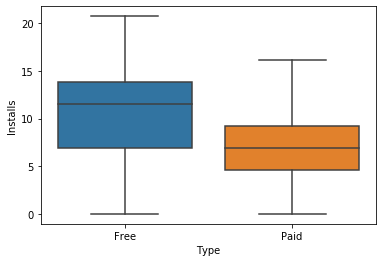

```python
# Visualize Number of downloads of paid apps vs. free apps. Hint (convert number of downloads to log in order to scale down actual value)
# Box plot is preferred.
import numpy as np
installs_log=np.log(apps.Installs[apps.Installs>0])
sns.boxplot(x="Type",y=installs_log,data=apps)
```

## 9. Sentiment analysis of user reviews

Mining user review data to determine how people feel about your product, brand, or service can be done using a technique called sentiment analysis. User reviews for apps can be analyzed to identify if the mood is positive, negative or neutral about that app. For example, positive words in an app review might include words such as 'amazing', 'friendly', 'good', 'great', and 'love'. Negative words might be words like 'malware', 'hate', 'problem', 'refund', and 'incompetent'.

Sentiment polarity defines sentiment with a range from +1 to -1 (+1 being positive, -1 being negative and 0 being neutral)

What is the sentiment trend of user reviews for paid and free apps?

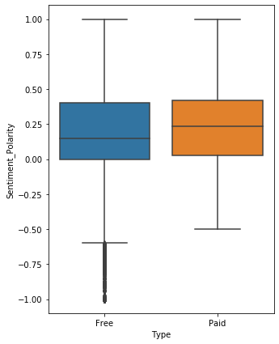

```python
# Load user_reviews.csv
user_reviews=pd.read_csv("datasets/user_reviews.csv")
# Join and merge the two dataframe apps and user_reviews. Drop NA values from Sentiment and Translated_Review columns
df2=pd.merge(apps,user_reviews,how="left")
df2=df2.dropna(subset=["Sentiment","Translated_Review"])
# Visualize user review sentiment polarity for paid vs. free apps. Hint (use Box plot for better visualization and analysis)
plt.figure(figsize=(5,7))
sns.boxplot(x="Type",y="Sentiment_Polarity",data=df2)
```

We first merge dataset using left join on apps, then we drop NA values from sentiment and translated reviews. From the graph we can see that free apps have average sentiment polarity between 0 and 0.25, while for paid apps it is about 0.25. So paid apps have a better sentiment polarity than free apps.